# Global report

Piotr Bystranowski

2025-02-27

## Sample

368 participants answered at least one question, while 234 participants completed the entire survey.

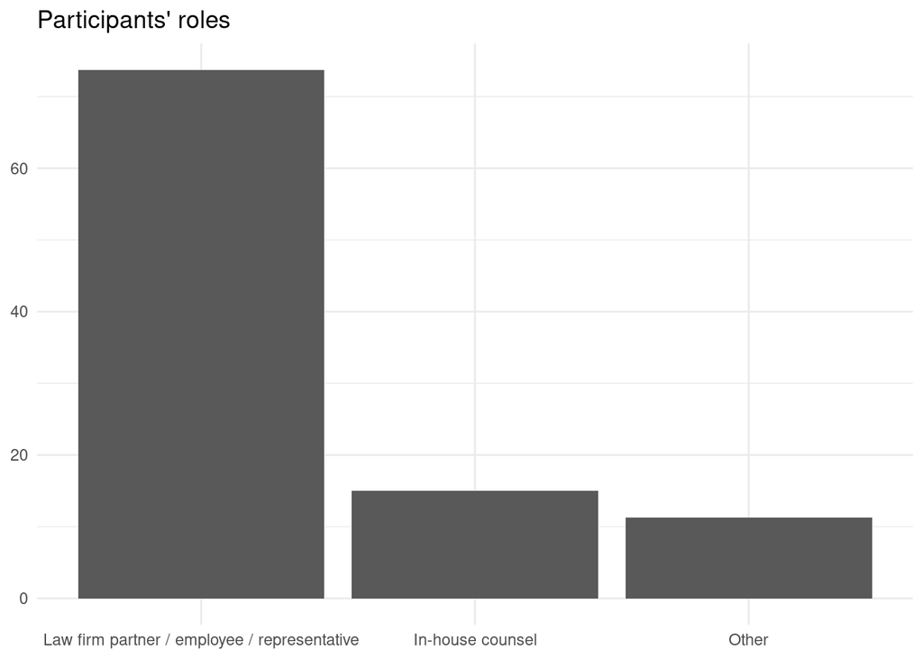

30 is the median number of employees in the participants’ organizations (max = 10^{5}, min = 0. 20 is the median number of lawyers in the participants’ organizations (max = 1.2^{4}, min = 0). 3 is the median number of laywers handling AI-based software for automating tasks considered specifically legal (max = 3000, min = 0). 1 is the median number of tech specialists handling AI-based software for automating tasks considered specifically legal (max = 150, min = 0).

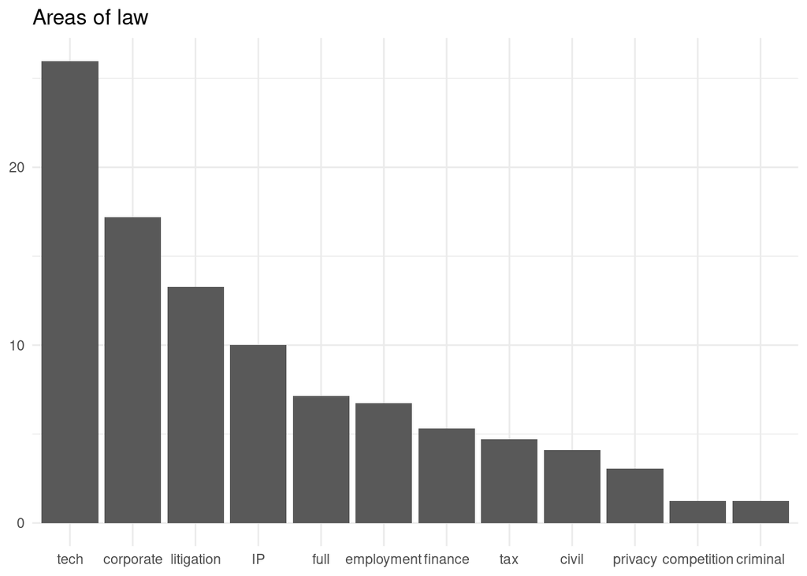

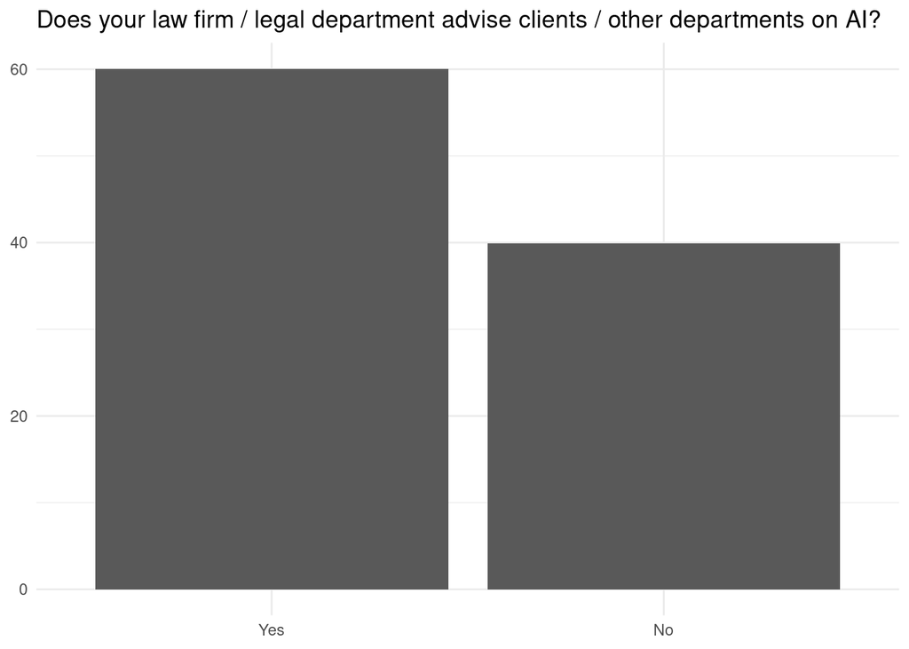

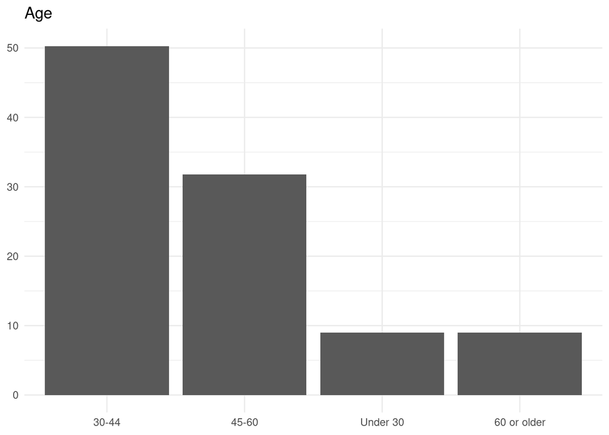